# Cellchat for analyzing intercellular communication

## Set the ligand-receptor interaction database

Users can update CellChatDB by adding their own curated ligand-receptor pairs.There is a vignette to do that

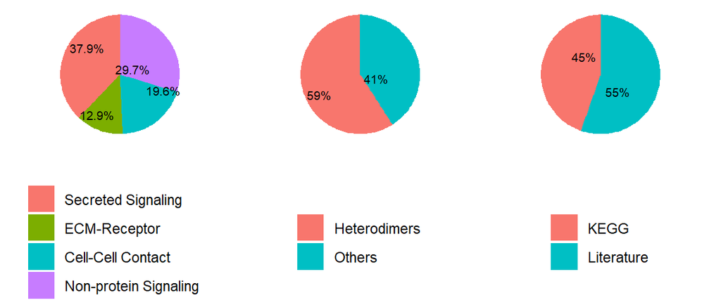

```r
CellChatDB <- CellChatDB.mouse # use CellChatDB.human if running on human data
showDatabaseCategory(CellChatDB)
```

```r
# You can look at the structure of the receptor-ligand pairs here
dplyr::glimpse(CellChatDB$interaction)
```

```
#> Rows: 3,379
#> Columns: 28
#> $ interaction_name         <chr> "TGFB1_TGFBR1_TGFBR2", "TGFB2_TGFBR1_TGFBR2",…
#> $ pathway_name             <chr> "TGFb", "TGFb", "TGFb", "TGFb", "TGFb", "TGFb…
#> $ ligand                   <chr> "Tgfb1", "Tgfb2", "Tgfb3", "Tgfb1", "Tgfb1", …
#> $ receptor                 <chr> "TGFbR1_R2", "TGFbR1_R2", "TGFbR1_R2", "ACVR1…
#> $ agonist                  <chr> "TGFb agonist", "TGFb agonist", "TGFb agonist…
#> $ antagonist               <chr> "TGFb antagonist", "TGFb antagonist", "TGFb a…
#> $ co_A_receptor            <chr> "", "", "", "", "", "", "", "", "", "", "", "…
#> $ co_I_receptor            <chr> "TGFb inhibition receptor", "TGFb inhibition …
#> $ evidence                 <chr> "KEGG: mmu04350", "KEGG: mmu04350", "KEGG: mm…
#> $ annotation               <chr> "Secreted Signaling", "Secreted Signaling", "…
#> $ interaction_name_2       <chr> "Tgfb1 - (Tgfbr1+Tgfbr2)", "Tgfb2  - (Tgfbr1+…
#> $ is_neurotransmitter      <lgl> FALSE, FALSE, FALSE, FALSE, FALSE, FALSE, FAL…
#> $ ligand.symbol            <chr> "Tgfb1", "Tgfb2", "Tgfb3", "Tgfb1", "Tgfb1", …
#> $ ligand.family            <chr> "TGF-beta", "TGF-beta", "TGF-beta", "TGF-beta…
#> $ ligand.location          <chr> "Extracellular matrix, Secreted, Extracellula…
#> $ ligand.keyword           <chr> "Disease variant, Signal, Reference proteome,…
#> $ ligand.secreted_type     <chr> "growth factor", "growth factor", "cytokine;g…
#> $ ligand.transmembrane     <lgl> FALSE, FALSE, TRUE, FALSE, FALSE, FALSE, FALS…
#> $ receptor.symbol          <chr> "Tgfbr1, Tgfbr2", "Tgfbr1, Tgfbr2", "Tgfbr1, …
#> $ receptor.family          <chr> "Protein kinase superfamily, TKL Ser/Thr prot…
#> $ receptor.location        <chr> "Cell membrane, Secreted, Membrane raft, Cell…
#> $ receptor.keyword         <chr> "Membrane, Secreted, Disulfide bond, Kinase, …
#> $ receptor.surfaceome_main <chr> "Receptors", "Receptors", "Receptors", "Recep…
#> $ receptor.surfaceome_sub  <chr> "Act.TGFB;Kinase", "Act.TGFB;Kinase", "Act.TG…
#> $ receptor.adhesome        <chr> "", "", "", "", "", "", "", "", "", "", "", "…
#> $ receptor.secreted_type   <chr> "", "", "", "", "", "", "", "", "", "", "", "…
#> $ receptor.transmembrane   <lgl> TRUE, TRUE, TRUE, TRUE, TRUE, TRUE, TRUE, TRU…
#> $ version                  <chr> "CellChatDB v1", "CellChatDB v1", "CellChatDB…
```

```r
# We will use "CellChatDB", which includes all of the receptor-ligand pairs - the default CellChatDB for cell-cell communication analysis
cellchat@DB <- CellChatDB

# However, you can use a subset of CellChatDB for cell-cell communication analysis
# For example, you can use Secreted Signaling
#CellChatDB.use <- subsetDB(CellChatDB, search = "Secreted Signaling")
# Then set the used database in the object
#cellchat@DB <- CellChatDB.use
```

## Preprocessing the expression data for cell-cell communication analysis

To infer the cell state-specific communications, CellChat identifies over-expressed ligands or receptors in one cell group and then identifies over-expressed ligand-receptor interactions if either ligand or receptor is over-expressed.

```r
# subset the expression data of signaling genes for saving computation cost
cellchat <- subsetData(cellchat) # This step is necessary even if using the whole database
cellchat <- identifyOverExpressedGenes(cellchat)
cellchat <- identifyOverExpressedInteractions(cellchat)
```

```
#> The number of highly variable ligand-receptor pairs used for signaling inference is 2831
```

```r
# project gene expression data onto PPI (Optional: when running it, USER should set `raw.use = FALSE` in the function `computeCommunProb()` in order to use the projected data)
# cellchat <- projectData(cellchat, PPI.human)
```

# Part II: Inference of cell-cell communication network

CellChat infers the biologically significant cell-cell communication by assigning each interaction with a probability value and peforming a permutation test. CellChat models the probability of cell-cell communication by integrating gene expression with prior known receptor-ligand interaction pairs using the law of mass action (meaning higher expression of ligand = stronger interaction).

The number of inferred ligand-receptor pairs clearly depends on the **method for calculating the average gene expression per cell group**. -CellChat uses ‘trimean’

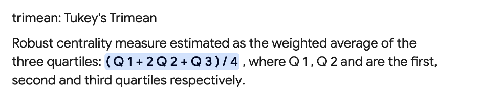

which produces fewer interactions than other methods. However, CellChat performs well at predicting stronger interactions, which is very helpful for narrowing down on interactions for further experimental validations.

In `computeCommunProb`, Cellchat provide’s an option for using other methods, such as 5% and 10% truncated mean, to calculating the average gene expression. Of note, ‘trimean’ approximates 25% truncated mean, implying that the average gene expression is zero if the percent of expressed cells in one group is less than 25%.

You can change that value, for example by specifiying a 10% truncated mean. Do this by setting `type = "truncatedMean"` and `trim = 0.1`. The function `computeAveExpr` can help to check the average expression of signaling genes of interest, e.g, `computeAveExpr(cellchat, features = c("CXCL12","CXCR4"), type = "truncatedMean", trim = 0.1)`.

When analyzing unsorted single-cell transcriptomes, under the assumption that abundant cell populations tend to send collectively stronger signals than the rare cell populations, CellChat can also consider the effect of cell proportion in each cell group in the probability calculation. USER can set `population.size = TRUE`.

## Compute the communication probability and infer cellular communication network

If well-known signaling pathways in the studied biological process are not predicted, USER can try `truncatedMean` to change the method for calculating the average gene expression per cell group.

This is a very long step, especially for large datasets

So it’s helpful to save the cellchat as a .rds object to load directly for future analysis.

```r
cellchat <- readRDS(here::here("Week 4 CellChat", "data", "CACPR_CellChat.rds"))

# cellchat <- computeCommunProb(cellchat)

# Filter out the cell-cell communication if there are only few number of cells in certain cell groups
# cellchat <- filterCommunication(cellchat, min.cells = 10)

# saveRDS(cellchat, file = here::here("Week 4 CellChat", "data", "CACPR_CellChat.rds"))

df.net <- subsetCommunication(cellchat)
```

## Extract the inferred cellular communication network as a data frame

We provide a function `subsetCommunication` to easily access the inferred cell-cell communications of interest. For example,

- `df.net <- subsetCommunication(cellchat)` returns a data frame consisting of all the inferred cell-cell communications at the level of ligands/receptors. Set `slot.name = "netP"` to access the the inferred communications at the level of signaling pathways
- `df.net <- subsetCommunication(cellchat, sources.use = c(1,2), targets.use = c(4,5))` gives the inferred cell-cell communications sending from cell groups 1 and 2 to cell groups 4 and 5.
- `df.net <- subsetCommunication(cellchat, signaling = c("WNT", "TGFb"))` gives the inferred cell-cell communications mediated by signaling WNT and TGFb.

## Infer the cell-cell communication at a signaling pathway level

CellChat computes the communication probability on signaling pathway level by summarizing the communication probabilities of all ligands-receptors interactions associated with each signaling pathway.

NB: The inferred intercellular communication network of each ligand-receptor pair and each signaling pathway is stored in the slot ‘net’ and ‘netP’, respectively.

```r
cellchat <- computeCommunProbPathway(cellchat)
```

## Calculate the aggregated cell-cell communication network

We can calculate the aggregated cell-cell communication network by counting the number of links or summarizing the communication probability. USER can also calculate the aggregated network among a subset of cell groups by setting `sources.use` and `targets.use`.

```r
cellchat <- aggregateNet(cellchat)

#You can visualize the significant pathways with the following command
cellchat@netP$pathways
```

```
#>  [1] "COLLAGEN"      "SPP1"          "LAMININ"       "APP"
#>  [5] "FGF"           "PTPRM"         "BMP"           "CDH"
#>  [9] "EGF"           "SLIT"          "SEMA3"         "NRG"
#> [13] "ADGRL"         "Cholesterol"   "VEGF"          "ADGRG"
#> [17] "CADM"          "EPHA"          "Netrin"        "THBS"
#> [21] "PDGF"          "PROS"          "ANGPTL"        "GAS"
#> [25] "SEMA6"         "CDH1"          "AGRN"          "UNC5"
#> [29] "TENASCIN"      "Glutamate"     "PECAM1"        "PTN"
#> [33] "RELN"          "DHEA"          "JAM"           "NECTIN"
#> [37] "NCAM"          "ANGPT"         "SEMA7"         "KLK"
#> [41] "Testosterone"  "HGF"           "Prostaglandin" "NOTCH"
#> [45] "CypA"          "EPHB"          "SEMA4"         "FLRT"
#> [49] "ADGRE"         "CD45"          "KIT"           "NGL"
#> [53] "BRADYKININ"    "HSPG"          "MPZ"           "CSF"
#> [57] "OCLN"          "GDF"           "PECAM2"        "CSPG4"
#> [61] "WNT"           "IGFBP"         "GAP"           "NRXN"
#> [65] "CDH5"          "CCL"           "CD39"          "PLAU"
#> [69] "CD46"          "ncWNT"         "ESAM"          "NEGR"
#> [73] "GRN"           "NPNT"          "CLDN"          "PVR"
#> [77] "Adenosine"     "CD96"
```

We can also visualize the aggregated cell-cell communication network. For example, showing the number of interactions or the total interaction strength (weights) between any two cell groups using circle plot.

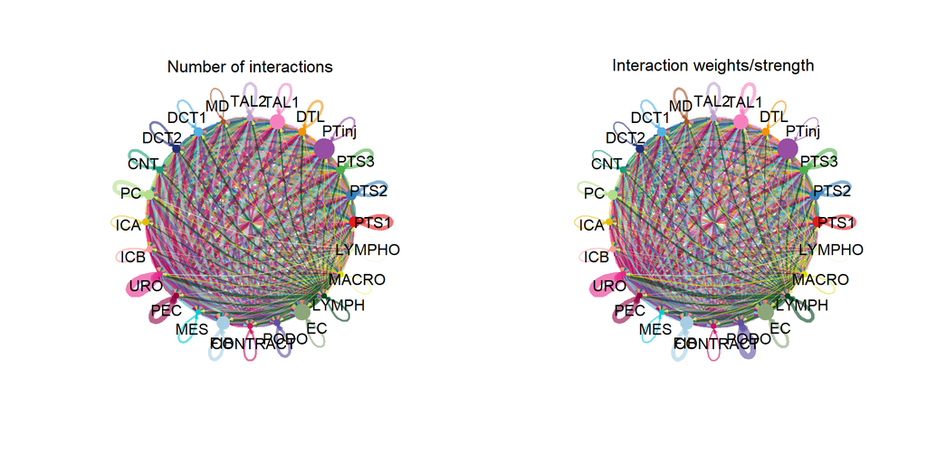

```r
groupSize <- as.numeric(table(cellchat@idents))
par(mfrow = c(1,2), xpd=TRUE)
netVisual_circle(cellchat@net$count, vertex.weight = groupSize, weight.scale = T, label.edge= F, title.name = "Number of interactions")
netVisual_circle(cellchat@net$weight, vertex.weight = groupSize, weight.scale = T, label.edge= F, title.name = "Interaction weights/strength")
```

Due to the complicated cell-cell communication network, we can examine the signaling sent from each cell group. Here we also control the parameter `edge.weight.max` so that we can compare edge weights between differet networks.

```r
mat <- cellchat@net$weight
par(mfrow = c(3,4), xpd=TRUE)
for (i in 1:nrow(mat)) {
  mat2 <- matrix(0, nrow = nrow(mat), ncol = ncol(mat), dimnames = dimnames(mat))
  mat2[i, ] <- mat[i, ]
  netVisual_circle(mat2, vertex.weight = groupSize, weight.scale = T, edge.weight.max = max(mat), title.name = rownames(mat)[i])
}
```

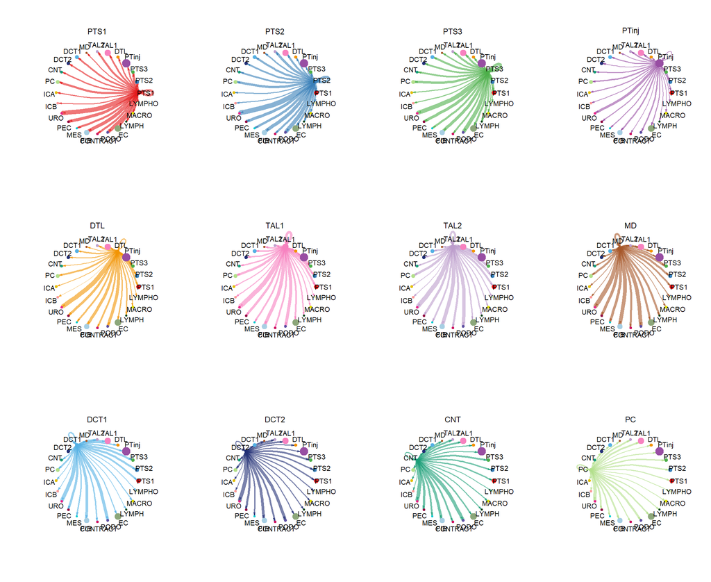

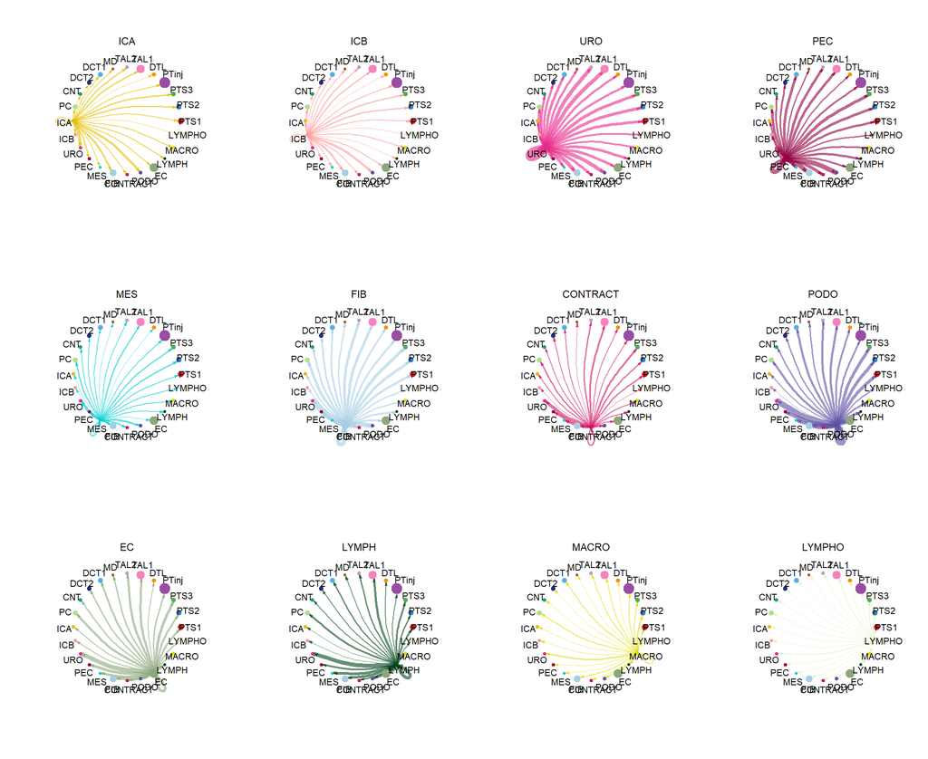

# Part III: Visualization of cell-cell communication network

Upon infering the cell-cell communication network, CellChat provides various functionality for further data exploration, analysis, and visualization.

- It provides several ways for visualizing cell-cell communication network, including hierarchical plot, circle plot, Chord diagram, and bubble plot.
- It provides an easy-to-use tool for extracting and visualizing high-order information of the inferred networks. For example, it allows ready prediction of major signaling inputs and outputs for cell populations and how these populations and signals coordinate together for functions.
- It can quantitatively characterize and compare the inferred cell-cell communication networks using an integrated approach by combining social network analysis, pattern recognition, and manifold learning approaches.

## Visualize each signaling pathway using Hierarchy plot, Circle plot or Chord diagram

**Hierarchy plot**: USER should define `vertex.receiver`, which is a numeric vector giving the index of the cell groups as targets in the left part of hierarchy plot. This hierarchical plot consist of two components: the left portion shows autocrine and paracrine signaling to certain cell groups of interest (i.e, the defined `vertex.receiver`), and the right portion shows autocrine and paracrine signaling to the remaining cell groups in the dataset. Thus, hierarchy plot provides an informative and intuitive way to visualize autocrine and paracrine signaling communications between cell groups of interest. For example, when studying the cell-cell communication between fibroblasts and immune cells, USER can define `vertex.receiver` as all fibroblast cell groups.

**Chord diagram**: CellChat provides two functions `netVisual_chord_cell` and `netVisual_chord_gene` for visualizing cell-cell communication with different purposes and different levels. `netVisual_chord_cell` is used for visualizing the cell-cell communication between different cell groups (where each sector in the chord diagram is a cell group), and `netVisual_chord_gene` is used for visualizing the cell-cell communication mediated by mutiple ligand-receptors or signaling pathways (where each sector in the chord diagram is a ligand, receptor or signaling pathway.)

**Explnations of edge color/weight, node color/size/shape**: In all visualization plots, edge colors are consistent with the sources as sender, and edge weights are proportional to the interaction strength. Thicker edge line indicates a stronger signal. In the **Hierarchy plot and Circle plot**, circle sizes are proportional to the number of cells in each cell group. In the hierarchy plot, solid and open circles represent source and target, respectively. In the **Chord diagram**, the inner thinner bar colors represent the targets that receive signal from the corresponding outer bar. The inner bar size is proportional to the signal strength received by the targets. Such inner bar is helpful for interpreting the complex chord diagram. Note that there exist some inner bars without any chord for some cell groups, please just igore it because this is an issue that has not been addressed by circlize package.

**Visualization of cell-cell communication at different levels**: One can visualize the inferred communication network of signaling pathways using `netVisual_aggregate`, and visualize the inferred communication networks of individual L-R pairs associated with that signaling pathway using `netVisual_individual`.

Here we take input of one signaling pathway as an example. All the signaling pathways showing significant communications can be accessed by `cellchat@netP$pathways`.

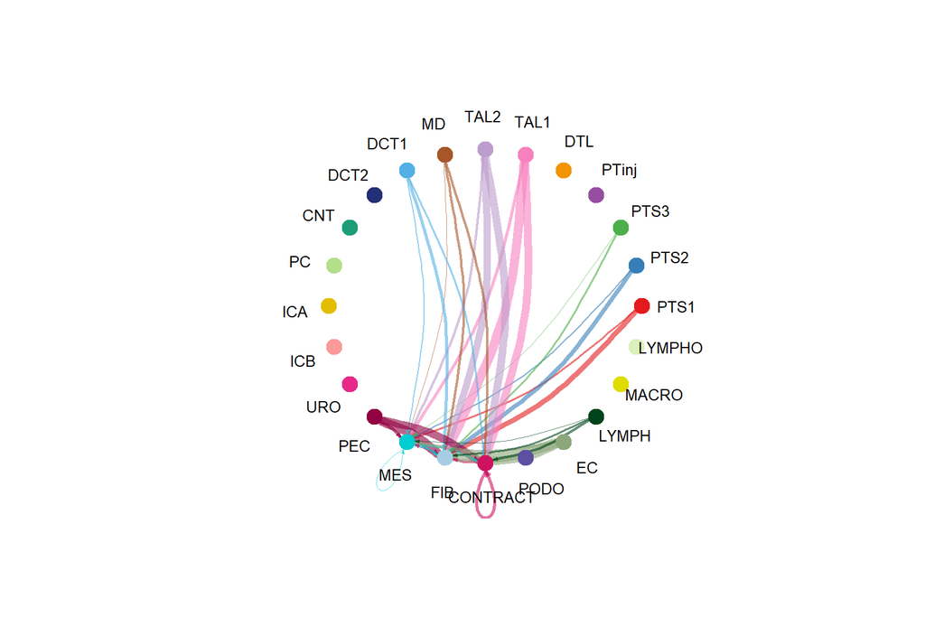

```r
pathways.show <- c("PDGF")
# Hierarchy plot
# Here we define `vertex.receive` so that the left portion of the hierarchy plot shows signaling to fibroblast and the right portion shows signaling to immune cells
netVisual_aggregate(cellchat, signaling = pathways.show,  vertex.receiver = vertex.receiver)
```

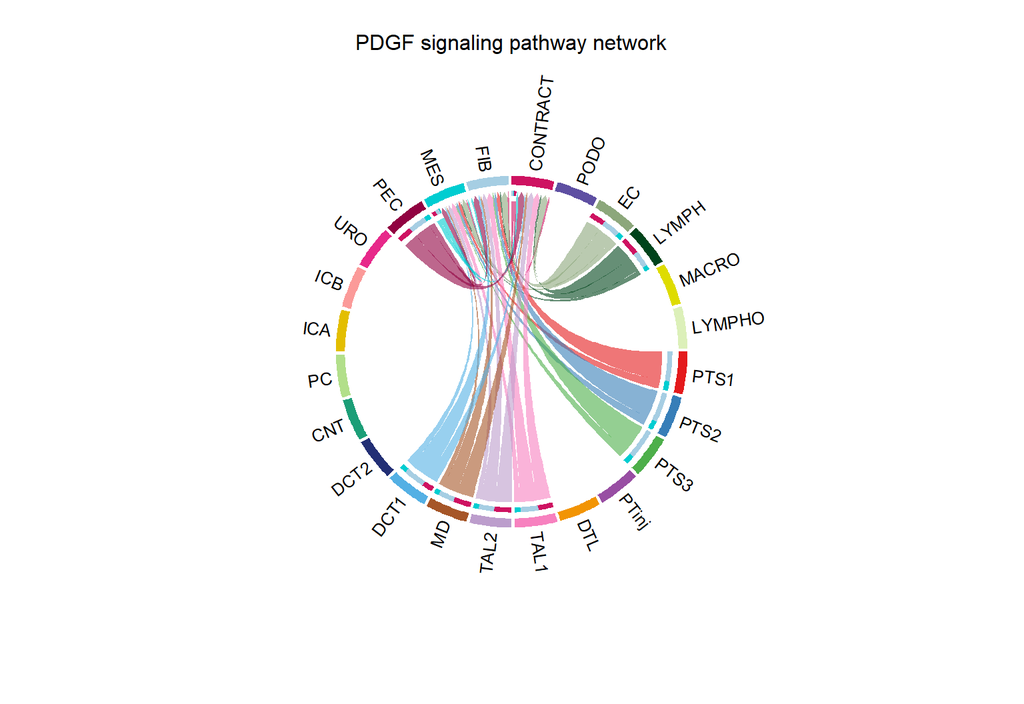

```r
# Circle plot
par(mfrow=c(1,1))
netVisual_aggregate(cellchat, signaling = pathways.show, layout = "circle")
# Chord diagram
par(mfrow=c(1,1))
netVisual_aggregate(cellchat, signaling = pathways.show, layout = "chord")
```

```
#> Do heatmap based on a single object
```

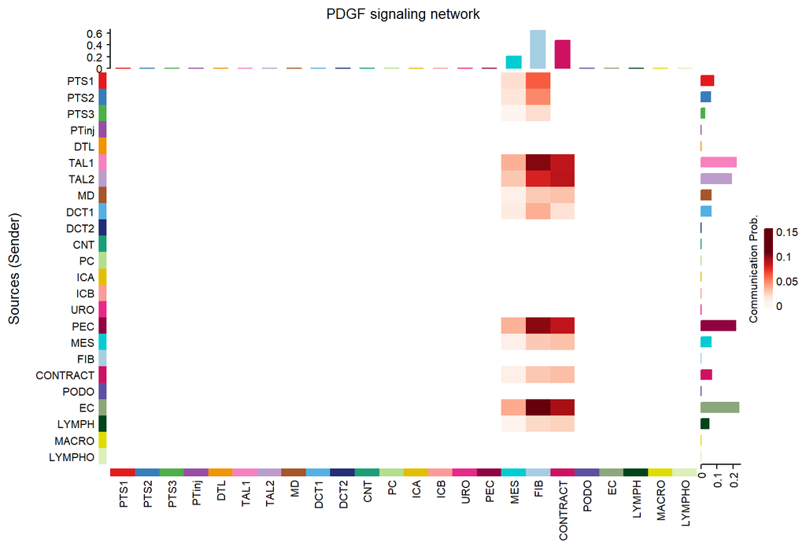

```r
# Heatmap
par(mfrow=c(1,1))
netVisual_heatmap(cellchat, signaling = pathways.show, color.heatmap = "Reds")
```

### Compute the contribution of each ligand-receptor pair to the overall signaling pathway and visualize cell-cell communication mediated by a single ligand-receptor pair

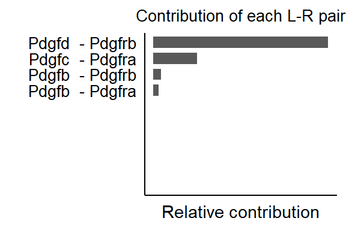

```r
netAnalysis_contribution(cellchat, signaling = pathways.show)
```

We can also visualize the cell-cell communication mediated by a single ligand-receptor pair. We provide a function `extractEnrichedLR` to extract all the significant interactions (L-R pairs) and related signaling genes for a given signaling pathway.

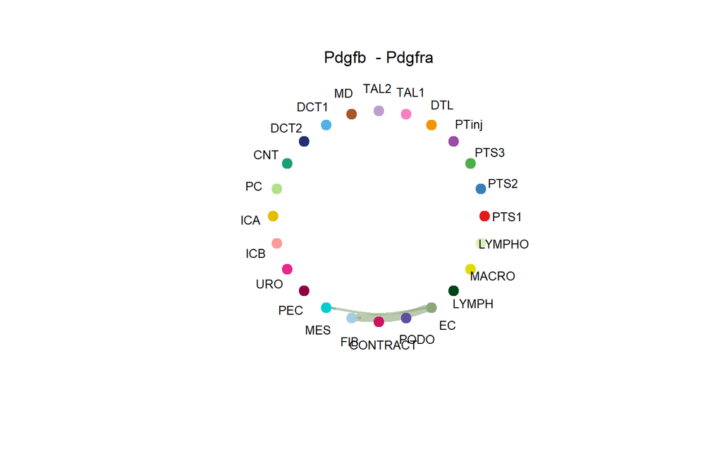

[output not shown]

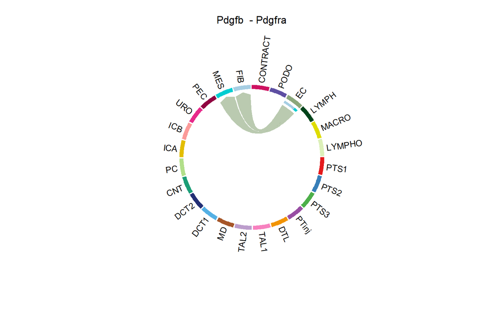

```r
pairLR.PDGF <- extractEnrichedLR(cellchat, signaling = pathways.show, geneLR.return = FALSE)
LR.show <- pairLR.PDGF[1,] # show one ligand-receptor pair
# Hierarchy plot
vertex.receiver = seq(1,4) # a numeric vector
netVisual_individual(cellchat, signaling = pathways.show,  pairLR.use = LR.show, vertex.receiver = vertex.receiver)
```

### Automatically save the plots of the all inferred network for quick exploration

In practical use, USERS can use ‘for … loop’ to automatically save the all inferred network for quick exploration using `netVisual`. `netVisual` supports an output in the formats of svg, png and pdf.

```r
# Access all the signaling pathways showing significant communications
pathways.show.all <- cellchat@netP$pathways
# check the order of cell identity to set suitable vertex.receiver
levels(cellchat@idents)
vertex.receiver = seq(1,4)
for (i in 1:length(pathways.show.all)) {
  # Visualize communication network associated with both signaling pathway and individual L-R pairs
  netVisual(cellchat, signaling = pathways.show.all[i], vertex.receiver = vertex.receiver, layout = "hierarchy")
  # Compute and visualize the contribution of each ligand-receptor pair to the overall signaling pathway
  gg <- netAnalysis_contribution(cellchat, signaling = pathways.show.all[i])
  ggsave(filename=paste0(pathways.show.all[i], "_L-R_contribution.pdf"), plot=gg, width = 3, height = 2, units = 'in', dpi = 300)
}
```

## Plot the signaling gene expression distribution using violin/dot plot

We can plot the gene expression distribution of signaling genes related to L-R pairs or signaling pathway using a Seurat wrapper function `plotGeneExpression`.

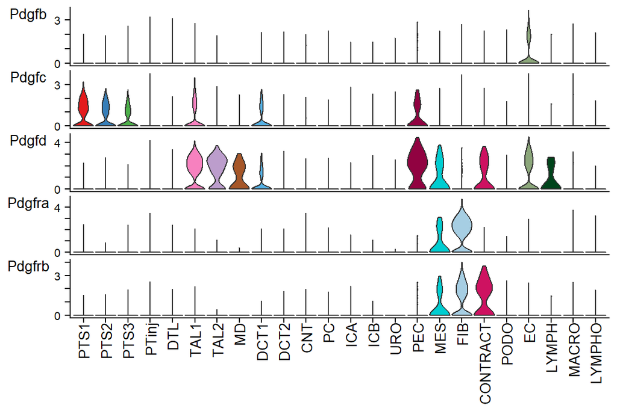

```r
plotGeneExpression(cellchat, signaling = "PDGF")
```

# Part IV: Systems analysis of cell-cell communication network

To facilitate the interpretation of the complex intercellular communication networks, CellChat quantitively measures networks through methods abstracted from graph theory, pattern recognition and manifold learning.

- It can determine major signaling sources and targets as well as mediators and influencers within a given signaling network using centrality measures from network analysis
- It can predict key incoming and outgoing signals for specific cell types as well as coordinated responses among different cell types by leveraging pattern recognition approaches.
- It can group signaling pathways by defining similarity measures and performing manifold learning from both functional and topological perspectives.
- It can delineate conserved and context-specific signaling pathways by joint manifold learning of multiple networks.

## Identify signaling roles (e.g., dominant senders, receivers) of cell groups as well as the major contributing signaling

CellChat allows ready identification of **dominant senders, receivers, mediators and influencers** in the intercellular communication network by computing several network centrality measures for each cell group. Specifically, we used measures in weighted-directed networks, including **out-degree, in-degree, flow betweenesss and information centrality**, to respectively identify dominant senders, receivers, mediators and influencers for the intercellular communications. In a weighteddirected network with the weights as the computed communication probabilities, the outdegree, computed as the sum of communication probabilities of the outgoing signaling from a cell group, and the in-degree, computed as the sum of the communication probabilities of the incoming signaling to a cell group, can be used to identify the dominant cell senders and receivers of signaling networks, respectively. For the definition of flow betweenness and information centrality, please check [our paper](https://www.biorxiv.org/content/10.1101/2020.07.21.214387v1) and related [reference](https://link.springer.com/article/10.1007/s12599-010-0127-3).

### Compute and visualize the network centrality scores

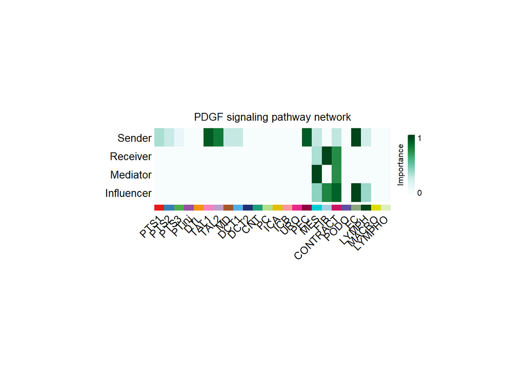

```r
# Compute the network centrality scores
cellchat <- netAnalysis_computeCentrality(cellchat, slot.name = "netP") # the slot 'netP' means the inferred intercellular communication network of signaling pathways
# Visualize the computed centrality scores using heatmap, allowing ready identification of major signaling roles of cell groups
netAnalysis_signalingRole_network(cellchat, signaling = pathways.show, width = 8, height = 2.5, font.size = 10)
```

### Visualize the dominant senders (sources) and receivers (targets) in a 2D space

We also provide another intutive way to visualize the dominant senders (sources) and receivers (targets) in a 2D space using scatter plot.

```r
# Signaling role analysis on the aggregated cell-cell communication network from all signaling pathways
gg1 <- netAnalysis_signalingRole_scatter(cellchat)
```

```
#> Signaling role analysis on the aggregated cell-cell communication network from all signaling pathways
```

```r
# Signaling role analysis on the cell-cell communication networks of interest
gg2 <- netAnalysis_signalingRole_scatter(cellchat, signaling = c("PDGF", "WNT"))
```

```
#> Signaling role analysis on the cell-cell communication network from user's input
```

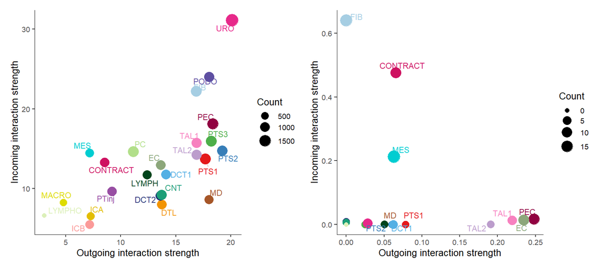

```r
gg1 + gg2
```

### Identify signals contributing most to outgoing or incoming signaling of certain cell groups

We can also answer the question on which signals contributing most to outgoing or incoming signaling of certain cell groups.

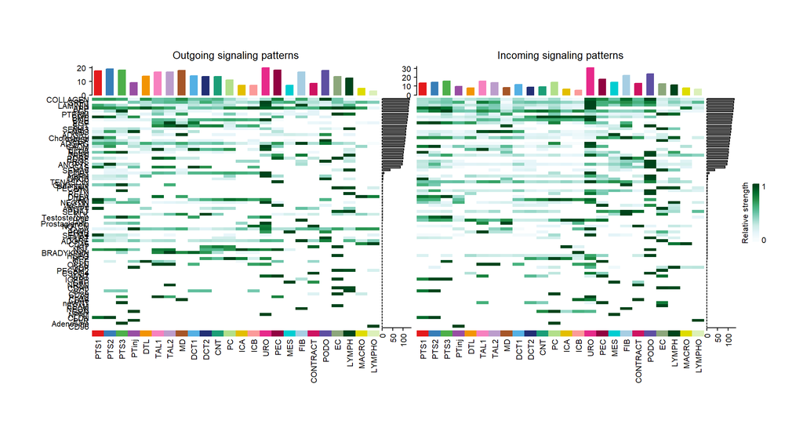

```r
# Signaling role analysis on the aggregated cell-cell communication network from all signaling pathways
ht1 <- netAnalysis_signalingRole_heatmap(cellchat, pattern = "outgoing")
ht2 <- netAnalysis_signalingRole_heatmap(cellchat, pattern = "incoming")
ht1 + ht2
```

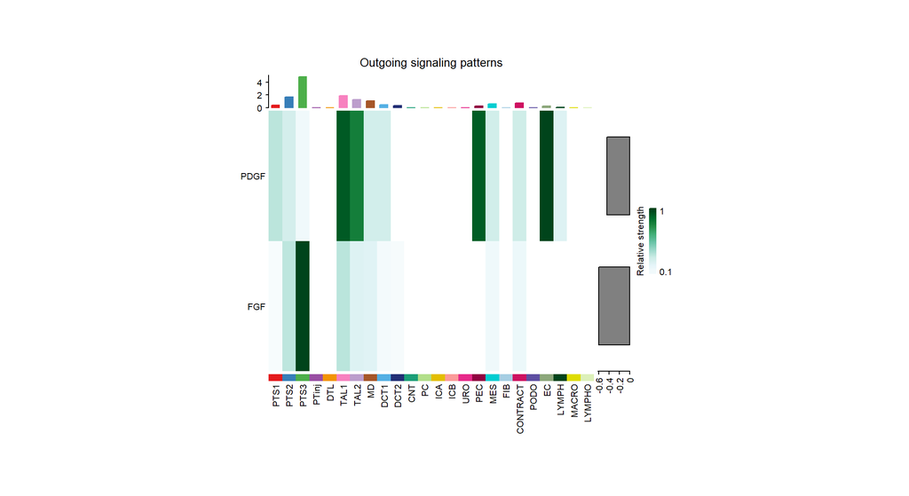

```r
# Signaling role analysis on the cell-cell communication networks of interest
ht <- netAnalysis_signalingRole_heatmap(cellchat, signaling = c("PDGF", "FGF"))
ht
```

## Identify global communication patterns to explore how multiple cell types and signaling pathways coordinate together

In addition to exploring detailed communications for individual pathways, an important question is how multiple cell groups and signaling pathways coordinate to function. CellChat employs a pattern recognition method to identify the global communication patterns.

## Manifold and classification learning analysis of signaling networks

Further, CellChat is able to quantify the similarity between all significant signaling pathways and then group them based on their cellular communication network similarity. Grouping can be done either based on the functional or structural similarity.

**Functional similarity**: High degree of functional similarity indicates major senders and receivers are similar, and it can be interpreted as the two signaling pathways or two ligand-receptor pairs exhibit similar and/or redundant roles. **The functional similarity analysis requires the same cell population composition between two datasets.**

**Structural similarity**: A structural similarity was used to compare their signaling network structure, without considering the similarity of senders and receivers.

### Identify signaling groups based on their functional similarity

```r
reticulate::py_install(packages = 'umap-learn')
```

```
#> Using virtual environment "C:/Users/jonat/OneDrive/Documents/.virtualenvs/r-reticulate" ...
#> + "C:/Users/jonat/OneDrive/Documents/.virtualenvs/r-reticulate/Scripts/python.exe" -m pip install --upgrade --no-user umap-learn
```

```r
cellchat <- computeNetSimilarity(cellchat, type = "functional")
cellchat <- netEmbedding(cellchat, type = "functional")
```

```
#> Manifold learning of the signaling networks for a single dataset
```

```r
cellchat <- netClustering(cellchat, type = "functional")
```

```
#> Classification learning of the signaling networks for a single dataset
```

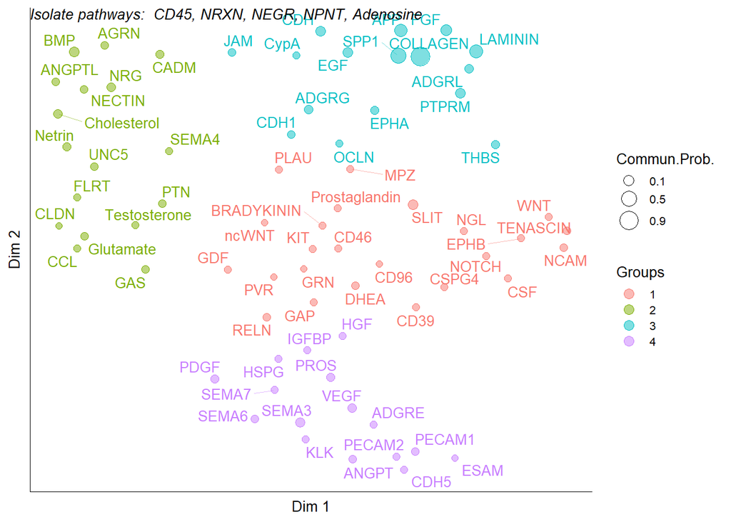

```r
# Visualization in 2D-space
netVisual_embedding(cellchat, type = "functional", label.size = 3.5)
```

```r
# netVisual_embeddingZoomIn(cellchat, type = "functional", nCol = 2)
```

### Identify signaling groups based on structure similarity

```r
cellchat <- computeNetSimilarity(cellchat, type = "structural")
cellchat <- netEmbedding(cellchat, type = "structural")
```

```
#> Manifold learning of the signaling networks for a single dataset
```

```r
cellchat <- netClustering(cellchat, type = "structural")
```

```
#> Classification learning of the signaling networks for a single dataset
```

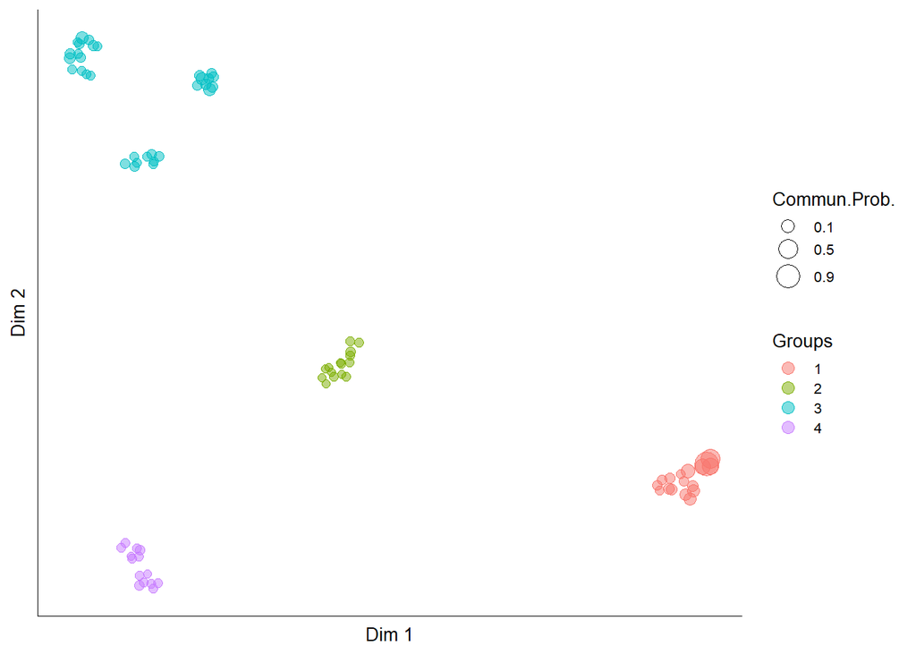

```r
# Visualization in 2D-space
netVisual_embedding(cellchat, type = "structural", label.size = 3.5)
```

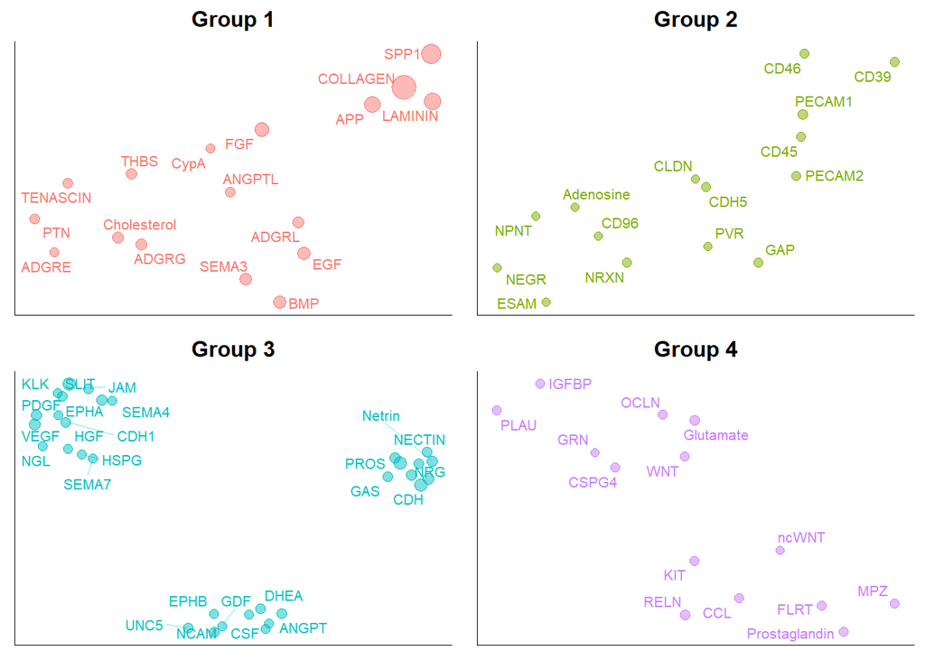

```r
netVisual_embeddingZoomIn(cellchat, type = "structural", nCol = 2)
```

# Part V: CellChat App

```r
runCellChatApp(cellchat)
```

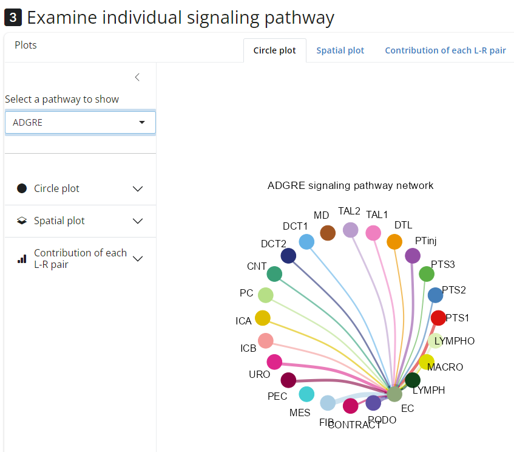

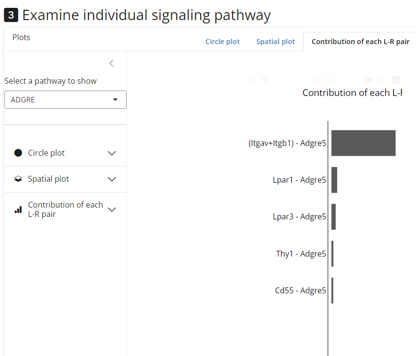